O modelo de regressão linear é bastante utilizado na predição de variáveis contínuas, onde há uma ou mais variáveis independentes e uma variável dependente (em que se busca comprovar uma hipótese sobre seu comportamento). Este é um modelo bastante simples de ser aplicado e um dos primeiros a ser ensinado nas aulas de econometria. Porém, apesar de sua simplicidade, para que o modelo gere resultados confiáveis, algumas premissas precisam ser satisfeitas, sendo elas:

1. Não existência de multicolinearidade entre as variáveis dependentes.
2. Não existência de autocorrelação na variável dependente.
3. Não existência de padrão no comportamento dos resíduos, ou seja, não ocorrência de heterocedasticidade.
4. Distribuição normal dos resíduos.

Satisfazendo estas premissas, o modelo pode ser executado e as conclusões geradas serão confiáveis para permitir a tomada de decisão. Neste post, irei analisar o comportamento dos resíduos com um exemplo prático para validar as premissas (iii) e (iv). Para isso, vou usar uma base de dados que apresenta o preço da cana de açucar como variável independente e a área plantada (em hectares) de cana de açucar, que será a variável dependente (a.k.a explicativa).

A ideia deste exemplo é analisar, através de um modelo de regressão linear simples, a elasticidade da oferta da cana de açucar em função do preço de venda. A hipótese é que existe elasticidade na oferta, onde a área plantada aumenta conforme o preço aumenta. Porém para validar esta elasticidade, é necessário comprovar, através da regressão, que as variáveis possuem correlação e a validade das premissas (iii) e (iv) ajudarão a apoiar esta conclusão.

Para este exemplo, serão utilizados os pacotes abaixo:

```r
library(tidyverse)
library(lmtest)
library(corrplot)
library(readxl)
library(gridExtra)
library(ggthemes)

# Definindo tema padrão dos gráficos
theme_set(theme_economist())
```

A base de dados deste exemplo contêm 34 registros, com informação de área plantada e preço da cana de açucar, ambos com a transformação em logarítmo natural inclusas.

Abaixo consta uma amostra dos dados:

| periodo | area | valor | log_area | log_valor |
| --- | --- | --- | --- | --- |
| 1 | 29 | 7.5258 | 3.367296 | 2.018337 |
| 2 | 71 | 11.4894 | 4.262680 | 2.441425 |
| 3 | 42 | 10.1075 | 3.737670 | 2.313278 |
| 4 | 90 | 11.0309 | 4.499810 | 2.400700 |
| 5 | 72 | 10.9562 | 4.276666 | 2.393906 |
| 6 | 57 | 13.2486 | 4.043051 | 2.583892 |
| 7 | 44 | 14.1783 | 3.784190 | 2.651713 |
| 8 | 61 | 20.9559 | 4.110874 | 3.042420 |
| 9 | 60 | 18.8259 | 4.094345 | 2.935234 |
| 10 | 70 | 19.5946 | 4.248495 | 2.975254 |

O modelo de regressão linear proposto para este exemplo é definido pela equação abaixo.

$$lnY_t = \beta_0+\beta_1 (lnX_t) + U_t$$

Onde:

$Y_t$ = área plantada no ano t (em hectares), em log natural

$X_t$ = preço no ano t, em log natural

$\beta_0$ = Intercepto da equação

$\beta_1$ = Inclinação da equação

$U_t$ = Ruído do modelo (variações não explicadas pelo modelo)

Utiliza-se o logarítmo natural para que as variações de um período para o outro (e.g. período 1 para o período 2) sejam intepretadas como variação percentual. Esta interpretação de variação percentual é possivel apenas para transformações em logarítmo natural e ela é necessária por conta do conceito de elasticidade, que indica que uma variação percentual de uma variável provoca uma determinada variação percentual em outra variável, como se fosse uma sensibilidade relativa.

Abaixo, consta um exemplo desta propriedade particular do log natural. Veja que as variações brutas podem ser interpretadas como variações percentuais após a transformação em log natural. Para mais informações veja [artigo 1](https://people.duke.edu/~rnau/411log.htm) [artigo 2](https://dev.to/rokaandy/logarithmic-transformation-in-linear-regression-models-why-when-3a7c).

| Valor | Crescimento | Log.natural | Delta |
| --- | --- | --- | --- |
| 100 | - | 4.605170 | - |
| 105 | 5.00% | 4.653960 | 4.88% |
| 112 | 6.67% | 4.718499 | 6.45% |
| 120 | 7.14% | 4.787492 | 6.9% |

Veja como o crescimento percentual dos valores (5.00%, 6.67% e 7.14%) ficam bem próximos do respectivo delta, que é a diferença entre o log natural do número com relação ao log natural do número anterior (e.g. 4.654 - 4.605 = 0.0488). Desta forma, se a equação estiver em logarítmo natural em ambos os lados, pode-se interpretar que a variação percentual na variável explicativa irá gerar uma variação percentual de $\beta_1$ na variável dependente.

Ao tentar criar esta mesma tabela com outros logarítmos (e.g. base 2 ou base 10), não se alcança os mesmos resultados. Portanto, esta interpretação e transformação só faz sentido com logaritmo natural.

| Valor | Crescimento | Log.natural | Delta |
| --- | --- | --- | --- |
| 100 | - | 6.643856 | - |
| 105 | 5.00% | 6.714246 | 7.04% |
| 112 | 6.67% | 6.807355 | 9.31% |
| 120 | 7.14% | 6.906891 | 9.95% |

| Valor | Crescimento | Log.natural | Delta |
| --- | --- | --- | --- |
| 100 | - | 2.000000 | - |
| 105 | 5.00% | 2.021189 | 2.12% |
| 112 | 6.67% | 2.049218 | 2.8% |
| 120 | 7.14% | 2.079181 | 3% |

Após entender esta propriedade do log natural, pode-se validar esta característica na tabela que será usada para o modelo de regressão. Os campos delta_area e delta_valor mostram a variação percentual de um período com relação ao período anterior. No campo delta_log_valor e delta_log_area é feita a diferença entre o período com o período anterior e os campos log_area_precision e log_valor_precision fazem a diferença entre delta_area com delta_log_area e delta_valor com delta_log_valor. Quanto mais baixo o valor de log_area_precision e log_valor_precision, mais forte é a característica do log natural explicada anteriormente. Veja abaixo para ficar mais claro:

| periodo | area | valor | log_area | log_valor | delta_area | delta_log_area | delta_valor | delta_log_valor | log_area_precicion | log_valor_precision |
| --- | --- | --- | --- | --- | --- | --- | --- | --- | --- | --- |
| 1 | 29 | 7.5258 | 3.367296 | 2.018337 | NA | NA | NA | NA | NA | NA |
| 2 | 71 | 11.4894 | 4.262680 | 2.441425 | 1.45 | 0.90 | 0.53 | 0.42 | 0.55 | 0.11 |
| 3 | 42 | 10.1075 | 3.737670 | 2.313278 | -0.41 | -0.53 | -0.12 | -0.13 | 0.12 | 0.01 |
| 4 | 90 | 11.0309 | 4.499810 | 2.400700 | 1.14 | 0.76 | 0.09 | 0.09 | 0.38 | 0.00 |
| 5 | 72 | 10.9562 | 4.276666 | 2.393906 | -0.20 | -0.22 | -0.01 | -0.01 | 0.02 | 0.00 |
| 6 | 57 | 13.2486 | 4.043051 | 2.583892 | -0.21 | -0.23 | 0.21 | 0.19 | 0.02 | 0.02 |
| 7 | 44 | 14.1783 | 3.784190 | 2.651713 | -0.23 | -0.26 | 0.07 | 0.07 | 0.03 | 0.00 |
| 8 | 61 | 20.9559 | 4.110874 | 3.042420 | 0.39 | 0.33 | 0.48 | 0.39 | 0.06 | 0.09 |
| 9 | 60 | 18.8259 | 4.094345 | 2.935234 | -0.02 | -0.02 | -0.10 | -0.11 | 0.00 | 0.01 |
| 10 | 70 | 19.5946 | 4.248495 | 2.975254 | 0.17 | 0.15 | 0.04 | 0.04 | 0.02 | 0.00 |

[output cut: 24 more lines]

Após entender um dos motivos da transformação em log, podemos continuar com a construção do modelo para validar as premissas dos resíduos. O modelo e os gráficos serão todos feitos com utilização das variáveis transformadas em log natural.

O gráfico abaixo mostra o comportamento das variáveis estudadas e a curva de regressão.

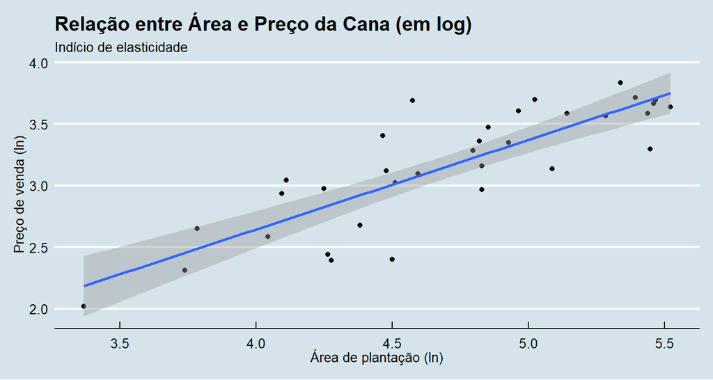

```r
dados_2 %>%
  ggplot(aes(x=log_area,y=log_valor))+
  geom_point()+
  geom_smooth(method = "lm",se = T)+
  labs(
    title = "Relação entre Área e Preço da Cana (em log)",
    subtitle= "Indício de elasticidade",
    x = "Área de plantação (ln)",
    y = "Preço de venda (ln)"
  )
```

Nota-se que as variáveis possuem correlação linear, ou seja, há elasticidade de oferta neste mercado. Abaixo consta o sumário do modelo de regressão:

```r
model <- lm(log_area~log_valor,data = dados_2)

summary(model)
```

```
##
## Call:
## lm(formula = log_area ~ log_valor, data = dados_2)
##
## Residuals:
##      Min       1Q   Median       3Q      Max
## -0.65076 -0.18823 -0.03096  0.24914  0.60492
##
## Coefficients:
##             Estimate Std. Error t value Pr(>|t|)
## (Intercept)   1.6416     0.3534   4.645 5.56e-05 ***
## log_valor     0.9706     0.1106   8.773 5.03e-10 ***
## ---
## Signif. codes:  0 '***' 0.001 '**' 0.01 '*' 0.05 '.' 0.1 ' ' 1
##
## Residual standard error: 0.3088 on 32 degrees of freedom
## Multiple R-squared:  0.7063, Adjusted R-squared:  0.6972
## F-statistic: 76.97 on 1 and 32 DF,  p-value: 5.031e-10
```

A equação de regressão gerada pelo modelo é definida como: $lnY_t = 1.64 + 0.97 (lnX_t) + U_t$

Esta equação indica que a plantação de cana de açucar seria de $e^{1.64} = 5.15$ hectares caso o preço fosse 0. Conforme o preço aumenta em 1% o impacto na área plantada será de 0.97%, pois ambas as variáveis estão transformadas em log natural, logo uma variação unitária é interpretada como variação percentual (conforme demonstrado acima).

O coeficiente de correlação (R²) ficou em 70.6%, o que mostra uma correlação significativa entre as variáveis. Porém, não basta apenas este resultado para gerar conclusões a respeito das variáveis estudadas, é preciso analisar as premissas com relação aos resíduos.

Abaixo é apresentado o gráfico de distribuição dos resíduos para validação da normalidade de seu comportamento. Tanto o histograma quanto o gráfico quantil-quantil (a.k.a qq-plot) são boas formas visuais de se validar a normalidade dos resíduos.

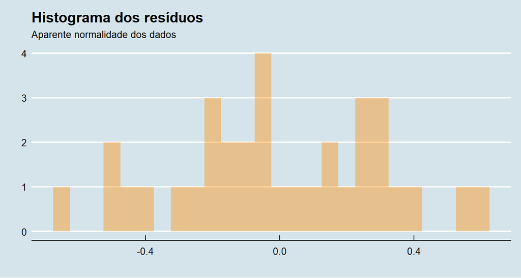

```r
df %>%
  ggplot(aes(x=residual))+
  geom_histogram(binwidth = .05,alpha=.4,fill="dark orange")+
  labs(
    title = "Histograma dos resíduos",
    subtitle = "Aparente normalidade dos dados",
    x = "",
    y = ""
  )
```

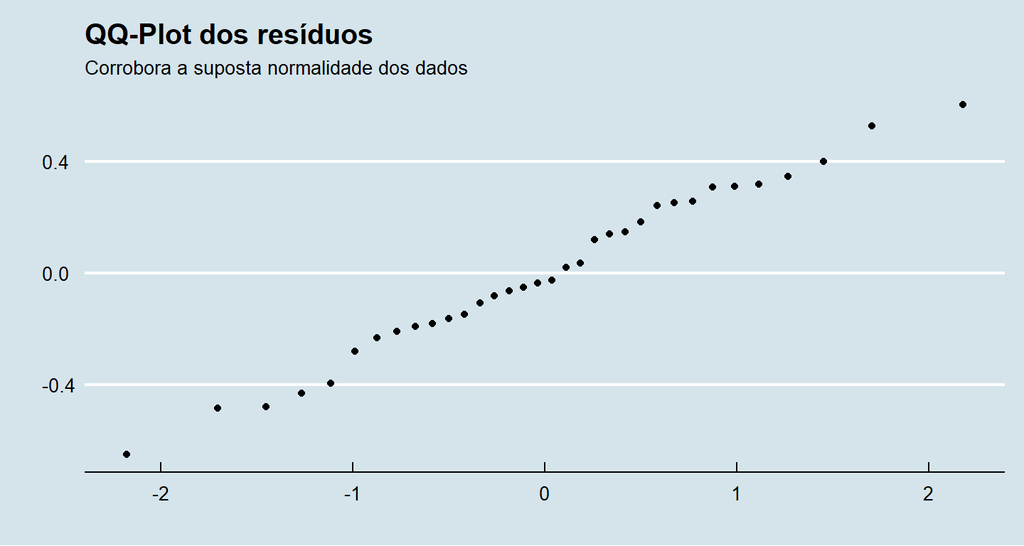

```r
df %>%
  ggplot(aes(sample=residual))+
  geom_qq()+
  labs(
    title = "QQ-Plot dos resíduos",
    subtitle = "Corrobora a suposta normalidade dos dados",
    x = "",
    y = ""
  )
```

A visualização gráfica é uma das formas para validar o comportamento dos resíduos porém não a única. Alguns testes formais podem ser usados para esta validação, como o Durbin-Watson, Breusch-Godfrey (a.k.a teste LM) e Ljung–Box Q test.

Aplicando ao exemplo proposto, o teste Durbin-Watson gerou os resultados abaixo:

```
##
##  Durbin-Watson test
##
## data:  model
## DW = 1.2912, p-value = 0.009801
## alternative hypothesis: true autocorrelation is greater than 0
```

O valor DW foi de 1.2912 e ele é usado para gerar a conclusão do teste. Para se concluir o teste, é preciso antes trazer os intervalos (DL e DU) que comparados com o valor DW. Para encontrar os valores de DL e DU veja esta [tablea](http://www.portalaction.com.br/analise-de-regressao/33-diagnostico-de-independencia).

**DL** = 1.35

**DU** = 1.49